# Chum Salmon Hatchery/Wild Interaction: Trial of adaptive (run timing) GTseq marker panel

## Summary

An adaptive marker panel associated with run timing variation in chum salmon was developed by ABL and used to genotype two plates of samples from the ADFG Alaska Hatchery Research Program study being conducted within SE Alaska. Samples were genotyped for 20 single nucleotide polymorphisms and weighted linear regressions were performed to assess the association of different SNPs with run timing (date of collection). Eight SNPs (four on LG29 and four on LG35) appear to be associated with run timing within these collections. The strength of association appears to vary by population. No markers on LGs 5, 23 or 15 appear to have a strong association with run timing within these collections.

## GTseq panel information

The current chum salmon adaptive marker panel was developed from variation detected between Yukon River summer (Gisasa River) and fall (Pelly River) run chum salmon with low coverage whole genome sequencing.These populations spawn approximately two months and over 1500 river km apart. We targeted the major peaks in differentiation with particular interest in markers within the genes leucine rich repeat containing nine (LRRC9; LG35) and estrogen receptor $\beta$ (ESRB; LG29) as they were associated with return timing in other salmonid species. After optimization, the final marker panel had 20 loci spread among 5 chromosomes.

```r
PPfile <- read_delim("../../Chum_RunTiming_GTseqPrimerProbe_20L.txt")

PPfile %>%
  mutate(LG = str_split(Locus,pattern="_") %>% lapply(.,"[[",2) %>% unlist())%>%
  group_by(LG)%>%
  summarize(nMarkers = n())%>%
  knitr::kable()%>%
  kableExtra::kable_styling(full_width = F)
```

| LG | nMarkers |
| --- | --- |
| LG15 | 5 |
| LG23 | 3 |
| LG29 | 4 |
| LG35 | 4 |
| LG5 | 4 |

The current primer probe file is *Chum_RunTiming_GTseqPrimerProbe_20L.txt*

## Chum Salmon Collections

The Alaska Department of Fish and Game sent us two plates of individuals from the Alaska Hatchery Research Program (AHRP) study that is being conducted in Southeast Alaska. ADFG developed a parentage panel that ABL may want to spike in some of the chum adaptive loci into if it helps to explain variation in run timing. We have samples from Prospect Creek and Fish Creek:

```r
MetaDat <- read.csv("./ProspectCreek_2017_2018_plateID_64545_FishCreek_2023_plateID_65642_lrrc9_latlong.csv")

MetaDat %>%
  group_by(location_code,year) %>%
  summarize(nSamps = n())%>%
  knitr::kable()%>%
  kableExtra::kable_styling(full_width = F)
```

| location_code | year | nSamps |
| --- | --- | --- |
| Fish Creek - Douglas Island | 2023 | 95 |
| Prospect Creek | 2017 | 21 |
| Prospect Creek | 2018 | 74 |

There appear to be very few samples from Prospect Creek from 2017. Let’s drop those samples and look at the number of fish per day. We plan to do a regression of allele frequency on day of year (doy) so we want to make sure we can estimate the allele frequenices for each day.

```r
MetaDat %>%
  filter(!(location_code == "Prospect Creek" & year == 2017))%>%
  group_by(location_code,year,doy) %>%
  summarize(nSamps = n())%>% ungroup()%>%
  knitr::kable()%>%
  kableExtra::kable_styling(full_width = F)
```

| location_code | year | doy | nSamps |
| --- | --- | --- | --- |
| Fish Creek - Douglas Island | 2023 | 202 | 2 |
| Fish Creek - Douglas Island | 2023 | 208 | 9 |
| Fish Creek - Douglas Island | 2023 | 209 | 13 |
| Fish Creek - Douglas Island | 2023 | 211 | 7 |
| Fish Creek - Douglas Island | 2023 | 213 | 9 |
| Fish Creek - Douglas Island | 2023 | 214 | 13 |
| Fish Creek - Douglas Island | 2023 | 215 | 10 |
| Fish Creek - Douglas Island | 2023 | 220 | 10 |
| Fish Creek - Douglas Island | 2023 | 223 | 5 |
| Fish Creek - Douglas Island | 2023 | 226 | 3 |
| Fish Creek - Douglas Island | 2023 | 232 | 2 |
| Fish Creek - Douglas Island | 2023 | 234 | 3 |
| Fish Creek - Douglas Island | 2023 | 238 | 4 |
| Fish Creek - Douglas Island | 2023 | 240 | 5 |
| Prospect Creek | 2018 | 204 | 1 |
| Prospect Creek | 2018 | 209 | 2 |
| Prospect Creek | 2018 | 212 | 2 |
| Prospect Creek | 2018 | 213 | 8 |
| Prospect Creek | 2018 | 217 | 11 |
| Prospect Creek | 2018 | 218 | 15 |
| Prospect Creek | 2018 | 225 | 1 |
| Prospect Creek | 2018 | 226 | 3 |
| Prospect Creek | 2018 | 230 | 3 |
| Prospect Creek | 2018 | 231 | 1 |
| Prospect Creek | 2018 | 234 | 4 |
| Prospect Creek | 2018 | 235 | 18 |
| Prospect Creek | 2018 | 238 | 3 |
| Prospect Creek | 2018 | 239 | 2 |

So there are quite a few days that we have pretty decent sample sizes (n > 10), but also a few where the sample size is low (n=2). I don’t really know the timing of the run versus when sampling was done so its hard to define ‘early’ and ‘late’. This is going to be a pretty cursory analysis so we will use weighted linear regression to account for some of those small sample sizes and not place too much emphasis on frequencies that are derived from a sample size of 2 fish.

## Adaptive Variation

All of the chum salmon from Fish and Prospect Creeks analyzed here were genotyped in the ‘ChumGTseq_Adaptive.RMD’ during optimization of the panel. We can read in the exported genotypes and quickly calculate some allele frequencies by the day of year (doy).

```r
ChumAdaptiveGenos <- read_delim("./polyGenResults_singleSNP_rubias.txt",col_types = cols(.default = "c")) %>%
  mutate(fish_no = gsub(pattern="^X",replacement = "", indiv) %>% as.numeric())%>%
  select(indiv,fish_no,starts_with("Oke"))%>%
  left_join(.,MetaDat,by='fish_no')%>%
  filter(!(location_code == "Prospect Creek" & year == 2017))

nloci <- length(grep("Oke",colnames(ChumAdaptiveGenos)))/2
loci <- grep(pattern = "Oke",x = colnames(ChumAdaptiveGenos),value=T)[c(T,F)] %>%gsub(pattern="_1$",replacement="",.)

#Calculate the number of each allele that we saw on each day
ChumAdaptiveObs <- lapply(1:nloci, function(x)
  ChumAdaptiveGenos %>%
  select(fish_no,location_code,doy,year,starts_with(loci[x]))%>%
  reshape2::melt(.,id.vars=c("fish_no","location_code","doy","year"))%>%
  group_by(location_code,doy,value)%>%
  summarize(n = n())%>%
  mutate(Locus = loci[x])
)%>%
  do.call(rbind,.)

# We need to account for alleles not observed on a given day, so we can
# make a table of all possible allele/day combinations
# and then just bind in our results.
# Anything not observed is a zero

ChumAdaptiveCx <- lapply(1:nloci, function(x)
  ChumAdaptiveGenos %>%
  select(fish_no,location_code,doy,year,starts_with(loci[x]))%>%
  reshape2::melt(.,id.vars=c("fish_no","location_code","doy","year"))%>%
    filter(!is.na(value))%>%
    ungroup()%>%
  expand(crossing(location_code,doy,value))%>%
  mutate(Locus =loci[x])
) %>%
  do.call(rbind,.)


ChumAdaptiveFreq <- ChumAdaptiveCx %>%
  left_join(.,ChumAdaptiveObs)%>%
  mutate(n = replace_na(n,0))%>%
  ungroup() %>%
  group_by(location_code,doy,Locus) %>%
  mutate(nAlleles = sum(n))%>%
  mutate(PropAllele = n/nAlleles)%>%
  mutate(SNP = paste(Locus,value,sep="_"))
```

Lets take a look at the two chromosomes first that we are most interested in: LG29 and LG35.

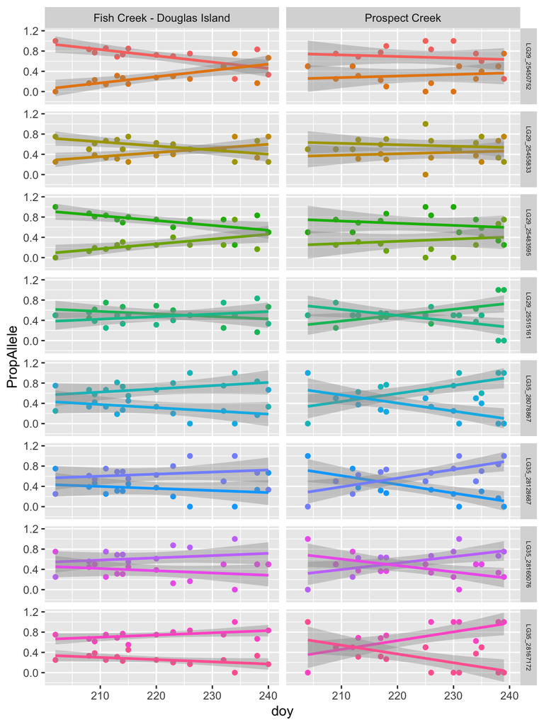

Figure 1: Weighted linear regression of allele frequency of SNPs on chromosomes 29 and 35 by day of year for Fish and Prospect Creeks in Southeast Alaska.

```r
ChumAdaptiveFreq %>%
  filter(grepl(pattern="LG35|LG29",Locus))%>%
  ungroup()%>%
  mutate(Locus = gsub(pattern = "OkeV2_",replacement = "",Locus))%>%
ggplot(., aes(y=PropAllele,x=doy,color=SNP,group_by(SNP)))+
  geom_point()+
  geom_smooth(method='lm', weight="nAlleles", formula= y~x)+
    facet_grid(Locus~location_code)+
  theme(strip.text.y = element_text(size = 5),
        legend.position = 'none')
```

This looks really good. The first thing we notice is that there are pretty large differences in trends between the two locations and it appears that the locus with the largest shift in frequency differs among collections. Fish Creek shows a pretty distinct shift in frequency for the first three LG29 SNPs with early samples have a very high MAF (~0.8-1) which shifts to intermediate frequencies over the course of the collection. If you squint, there may be a similar pattern in Prospect Creek. Prospect Creek collections show the opposite shift for LG35 SNPs - allele frequencies at intermediate values which diverge to near fixation by the end of the sampling period.

We can look at the weighted linear regressions for the remaining three chromosomes: LG5, 15 and 23.

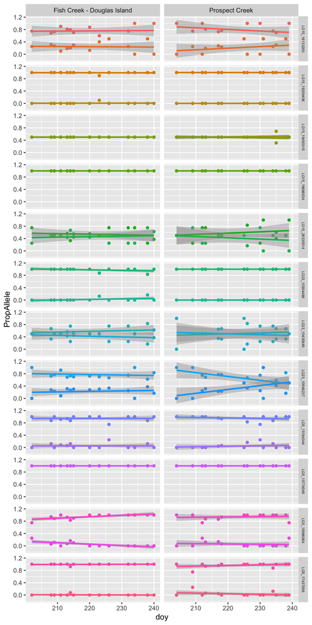

Figure 2: Weighted linear regression of allele frequency for SNPs on Chromosomes 5, 15, and 23 by day of year for Fish and Prospect Creeks in Southeast Alaska.

```r
ChumAdaptiveFreq %>%
  filter(grepl(pattern="LG5|LG15|LG23",Locus))%>%
  ungroup()%>%
  mutate(Locus = gsub(pattern = "OkeV2_",replacement = "",Locus))%>%
ggplot(., aes(y=PropAllele,x=doy,color=SNP,group_by(SNP)))+
  geom_point()+
  geom_smooth(method='lm', weight="nAlleles", formula= y~x)+
    facet_grid(Locus~location_code)+
  theme(strip.text.y = element_text(size = 5),
        legend.position = 'none')
```

Yeah, most of these are pretty bleh. Two loci appear to be fixed in both collections (LG5_15774549 , LG15_19686534). There also something going on with LG23_10546237 in Prospect Creek, but not so much in Fish Creek.

Overall the results from LG29 and LG35 are promising and variation in these SNPs should be surveyed for a larger collection of samples.